# Part 2 - Introduction to NumPy

# Table of Contents

## Introduction to NumPy

**[NumPy](https://numpy.org/)**, short for Numerical Python, is the core library for scientific computing in Python. It has been designed specifically for performing basic and advanced array operations. It primarily supports multi-dimensional arrays and vectors for complex arithmetic operations. Here are some things you will find in NumPy:

1. `ndarray`, an efficient multidimensional array object providing fast array-oriented arithmetic operations and flexible broadcasting capabilities.
2. Mathematical functions for fast operations on entire arrays of data without having to write loops.
3. Tools for reading/writing array data to disk and working with memory-mapped files.
4. Linear algebra, random number generation, and Fourier transform capabilities.

NumPy arrays form the core of nearly the entire ecosystem of data science tools in Python. They provide:

- Efficient storage and data operations as they use much less memory than built-in Python sequences.
- Ability to perform complex computations on large blocks of data without the need for using Python for loops.
- Performance as arrays are much faster than Python core library provided [Lists](https://docs.python.org/3/tutorial/introduction.html#lists).

NumPy by itself does not provide modeling or scientific functionality, but an understanding of NumPy arrays and array-oriented computing will help you use tools, such as pandas, much more effectively.

### Installation and Import

A typical installation of Python API comes with Numpy. You can use `pip` or `conda` to install it.

```python
# conda install numpy
# pip install numpy
```

Once NumPy is installed, you can import it as:

```python
import numpy as np
```

You can also check the version of NumPy that is installed:

```python
np.__version__
```

```
'1.18.5'
```

## Creating Arrays

One of the key features of NumPy is its N-dimensional array object `ndarray`. An `ndarray` is a generic multidimensional container for homogeneous data; that is, all of the elements in the array must be the same type. So, an array is like a grid of values, all of the same type. The values in an array are indexed by a tuple of nonnegative integers.

### Creating N-dimensional Array

The easiest way to create an array is to use the `array` function. We can initialize numpy arrays from Python lists. Let's create one, two, and three dimensional arrays using lists.

```python
# Create one-dimensional array
data1 = [1,2,3,6,7]
arr1 = np.array(data1)
arr1
```

```
array([1, 2, 3, 6, 7])
```

```python
# Create two and three dimensional arrays
data2 = [[1,2,3,6], [2,6,9,11]]
data3 = [[[1, 2], [3, 4]], [[5, 6], [7, 8]]]

arr2 = np.array(data2)
arr3 = np.array(data3)

print('2D array:\n', arr2)
print('\n')
print('3D array:\n', arr3)
```

```
2D array:
 [[ 1  2  3  6]
 [ 2  6  9 11]]


3D array:
 [[[1 2]
  [3 4]]

 [[5 6]
  [7 8]]]
```

#### Creating arrays using random number generator

We can also generate arrays using NumPy's random number generator. Numpy's `np.random` module contains `rand`, `randn` and `randint` functions that can be used to generate different random numbers from different distributions.

- `rand` - generates random samples from [uniform distribution](https://en.wikipedia.org/wiki/Continuous_uniform_distribution) between 0 and 1. We specify the shape of the resulting array we want.
- `randn` - generates random samples from [normal distribution](https://en.wikipedia.org/wiki/Normal_distribution) with mean 0 and standard deviation 1. We specify the shape of the resulting array we want.
- `randint` - generates random integers from a given low and high value range. We specify the min and max values for random number generation and also the shape of the resulting array we want.

Let's create a 2-D array using `rand`.

```python
# Arrays using rand
r1 = np.random.rand(2,4)
r1
```

```
array([[0.80668187, 0.04487517, 0.05382909, 0.79854817],
       [0.64946385, 0.8975755 , 0.79676167, 0.53641035]])
```

Now, let's create a 3-D array using `randn`.

```python
# Arrays using rand
r2 = np.random.randn(2,3,2)
r2
```

```
array([[[ 0.76102009, -1.40584035],
        [-1.29607784,  0.27082671],
        [-0.32464382, -0.46424713]],

       [[-2.13802959,  1.05216567],
        [-0.37643712,  0.45702234],
        [-0.74756525,  0.1225769 ]]])
```

Let's create a 2-D array of random integers between 2 and 10 using `randint`.

```python
r3 = np.random.randint(2,10, size=(2, 4))  # Two-dimensional array
r3
```

```
array([[2, 9, 7, 6],
       [6, 3, 3, 6]])
```

### Attibutes of a NumPy Array

Each array has attributes such as:

- `ndim` (the number of dimensions)
- `shape` (the size of each dimension)
- `size` (the total size of the array)
- `dtype` (the data type of the array)

Let's look at each of these attributes. We will use array **r2** defined above to check these attributes. These attributes are extremely useful and come in handy during the *data exploration* phase of a project.

`ndim`: Number of dimensions

```python
r2.ndim
```

```
3
```

`shape`: Size of each dimension

```python
r2.shape
```

```
(2, 3, 2)
```

`size`: Total number of elements in the array

```python
r2.size
```

```
12
```

`dtype`: Data type of the array

```python
r2.dtype
```

```
dtype('float64')
```

## Navigating Arrays

Elements of an array can be accessed in multiple ways. We can use `[]` to access individual elements on an array. We can also use slice notation, marked by the colon (:) character to access subarrays. Indexing and slicing of NumPy arrays is very similar to Python [Lists](https://docs.python.org/3/tutorial/datastructures.html).

### Array Indexing - Accessing Single Elements

In a one-dimensional array, the value can be accessed by specifying the desired index. In a multi-dimensional array, value can be accessed using a comma-separated indices. We will use arrays defined above to look at some examples.

```python
# Print arrays
print('1D array:\n', arr1)
print('2D array:\n', arr2)
print('3D array:\n', arr3)
```

```
1D array:
 [1 2 3 6 7]
2D array:
 [[ 1  2  3  6]
 [ 2  6  9 11]]
3D array:
 [[[1 2]
  [3 4]]

 [[5 6]
  [7 8]]]
```

#### One-dimensional Array

```python
# Access value at index 0
arr1[0]
```

```
1
```

```python
# Access value at index 2
arr1[2]
```

```
3
```

To index from the end of the array, you can use negative indices.

```python
arr1[-1]
```

```
7
```

```python
arr1[-3]
```

```
3
```

#### Multi-dimensional Array

In a multi-dimensional array, the elements at each index are no longer scalars but rather sub-arrays. Elements of a multi-dimensional array can be accessed using a comma-separated list of indices. If you omit later indices, the returned object will be a sub-array. Let's take a look.

**2-D Array**

```python
# Print array
arr2
```

```
array([[ 1,  2,  3,  6],
       [ 2,  6,  9, 11]])
```

```python
# Access value at index [0]
arr2[0]
```

```
array([1, 2, 3, 6])
```

Accessing $0^{th}$ index resulted in a sub-array at index 0. To access a specific element, we can pass a list of indices.

```python
# Access value at index [0,0]
arr2[0,0]
```

```
1
```

```python
# Access value at index [1,2]
arr2[1,2]
```

```
9
```

**3-D Array**

```python
# Print array
arr3
```

```
array([[[1, 2],
        [3, 4]],

       [[5, 6],
        [7, 8]]])
```

```python
# Access value at index [0]
arr3[0]
```

```
array([[1, 2],
       [3, 4]])
```

Accessing $0^{th}$ index resulted in a sub-array at index 0. To access a specific element, we can pass a list of indices.

```python
# Access a specific element
arr3[0,1,1]
```

```
4
```

### Array Slicing

We can use slice notation, marked by the colon (:) character to access sub-arrays of `ndarrays`. To access a slice of an array x, we can use the NumPy slicing syntax `x[start:stop:slice]`. Let's look at accessing sub-arrays in one dimension and in multiple dimensions.

```python
# Print arrays
print('1D array:\n', arr1)
print('2D array:\n', arr2)
print('3D array:\n', arr3)
```

```
1D array:
 [1 2 3 6 7]
2D array:
 [[ 1  2  3  6]
 [ 2  6  9 11]]
3D array:
 [[[1 2]
  [3 4]]

 [[5 6]
  [7 8]]]
```

#### One-dimensional Array

```python
# first three elements
arr1[:3]
```

```
array([1, 2, 3])
```

```python
# elements after index 2
arr1[2:]
```

```
array([3, 6, 7])
```

```python
# middle sub-array
arr1[1:4]
```

```
array([2, 3, 6])
```

```python
# every other element
arr1[::2]
```

```
array([1, 3, 7])
```

```python
# all elements reversed
arr1[::-1]
```

```
array([7, 6, 3, 2, 1])
```

#### Multi-dimensional Array

Slices in a multi-dimensional array can be accessed using a comma-separated list of indices. If you omit later indices, the returned object will be a sub-array. Let's take a look.

```python
# Print data
arr2
```

```
array([[ 1,  2,  3,  6],
       [ 2,  6,  9, 11]])
```

```python
# two rows, two columns
arr2[:2, :2]
```

```
array([[1, 2],
       [2, 6]])
```

```python
# all rows, every other column
arr2[:, ::2]
```

```
array([[1, 3],
       [2, 9]])
```

Indexing and Slicing can be combined to access single rows or columns on an array.

```python
# first row
arr2[0, :]
```

```
array([1, 2, 3, 6])
```

```python
# first column
arr2[:, 0]
```

```
array([1, 2])
```

### Reshaping Arrays

Arrays can be converted from one shape to another without copying any data. To do this, we can pass a tuple indicating the new shape to the `reshape` array instance method. By reshaping an array, we can add or remove dimensions or change the number of elements in each dimension. Let's take a look.

#### One-dimensional Array

```python
# Print array and its shape
print('Array:', arr1)
print('Shape of array:', arr1.shape)
```

```
Array: [1 2 3 6 7]
Shape of array: (5,)
```

```python
# Reshape 1-D array into 1 row and 5 columns
arr1.reshape(1,5)
```

```
array([[1, 2, 3, 6, 7]])
```

```python
# Print shape after reshaping
arr1.reshape(1,5).shape
```

```
(1, 5)
```

```python
# Reshape 1-D array into 5 rows and 1 column
arr1.reshape(5,1)
```

```
array([[1],
       [2],
       [3],
       [6],
       [7]])
```

```python
# Print shape after reshaping
arr1.reshape(5,1).shape
```

```
(5, 1)
```

When reshaping, the size of the reshaped array must match the total number of elements in the actual array. For example, an array of 5 elements cannot be reshaped to (2,3) or (3,2) arrays. When this computation is performed, an error will be generated as shown.

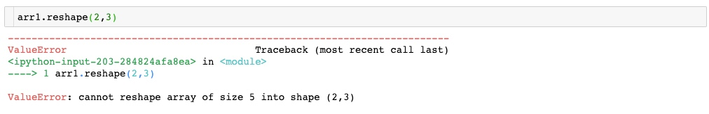

The error shows that an array of size 5 `arr1` cannot be reshaped into an array of size 6 (2 x 3).

#### Multi-dimensional Array

```python
# Create data
arr = np.arange(12).reshape((6, 2))
print('Array:\n', arr)
print('Shape of array:', arr.shape)
```

```
Array:
 [[ 0  1]
 [ 2  3]
 [ 4  5]
 [ 6  7]
 [ 8  9]
 [10 11]]
Shape of array: (6, 2)
```

**Reshape** the array to shape (4,3)

```python
# 4 rows and 3 columns
arr.reshape(4,3)
```

```
array([[ 0,  1,  2],
       [ 3,  4,  5],
       [ 6,  7,  8],
       [ 9, 10, 11]])
```

#### Transposing an Array

**Transposing** is a special form of reshaping that swaps the axes. To transpose an array, simply use the `T` attribute of an array object.

```python
# Transpose of array
arr.T
```

```
array([[ 0,  2,  4,  6,  8, 10],
       [ 1,  3,  5,  7,  9, 11]])
```

`arr` is of shape (6,2). Transposing this array swaps the axes to return a shape of (2,6).

#### Flattening an Array

The opposite operation of reshape from one-dimensional to a higher dimension is typically known as flattening.

```python
# Flatten array
arr.flatten()
```

```
array([ 0,  1,  2,  3,  4,  5,  6,  7,  8,  9, 10, 11])
```

```python
# Check shape
arr.flatten().shape
```

```
(12,)
```

`arr` of shape (6,2) is flattened to return a shape of (12,).

## Array Computation

### Vectorization

Computation on **NumPy** arrays can be very fast, or it can be very slow, and the key to making it fast, is to use **Vectorization**. The practice of replacing explicit loops with array expressions is commonly referred to as vectorization. In NumPy arrays, this is accomplished by simply performing an operation on the array, which will then be applied to each element. Vectorized operations will often be one or two (or more) orders of magnitude faster than their pure Python equivalents. Let's look at an example.

Imagine we have an array of values and would like to compute the sum of values. A straightforward approach using explicit loops might look like this:

```python
%%time
# Sum using loops
total = 0
for i in np.arange(1000000):
    total += i
total
```

```
CPU times: user 228 ms, sys: 3.68 ms, total: 231 ms
Wall time: 230 ms
```

```
499999500000
```

Python is unable to take advantage of the fact that the array’s contents are all of a single data type. It first examines the object's type and does a dynamic lookup of the correct function to use for that type, which slows down the computation massively.

Recall that NumPy’s `ndarray` are homogeneous: an array can only contain data of a single type. NumPy takes advantage of the fact and delegates the task of performing mathematical operations on the array’s contents to optimized, compiled code. The result is a tremendous speedup over the explicit loops in Python.

Let's use the vectorized function `np.sum()` and time how long it takes to run the computation.

```python
%%time
np.sum(np.arange(1000000))
```

```
CPU times: user 2.87 ms, sys: 3.2 ms, total: 6.07 ms
Wall time: 4.65 ms
```

```
499999500000
```

### Universal Functions

A universal function "*ufunc*" is a function that performs element-wise operations on data in ndarrays. *ufuncs* exist in two flavors:

- Unary ufuncs: operate on a single input
- Binary ufuncs: operate on two inputs

A complete list of NumPy universal functions can be found [here](https://numpy.org/doc/stable/reference/ufuncs.html#available-ufuncs). Let's look at some examples of *ufuncs*.

#### Single Array - Examples

The examples illustrate universal functions being applied to a single array.

```python
# Create array
arr1 = np.arange(2,8)
arr1
```

```
array([2, 3, 4, 5, 6, 7])
```

```python
# Univariate Operations
print('Addition        :', np.add(arr1,2))
print('Multiplication  :', np.multiply(arr1,2))
print('Exponentiation  :', np.power(arr1,2))
print('Square Root     :', np.sqrt(arr1))
print("ln(x)           :", np.log(arr1))
print("log2(x)         :", np.log2(arr1))
print("Exponential(e^x):", np.exp(arr1))
print("2^x             :", np.exp2(arr1))
print("Minimum         :", np.min(arr1))
print("Maximum         :", np.max(arr1))
print("Mean            :", np.mean(arr1))
print("St.Deviation    :", np.std(arr1))
print("Sum of elements :", np.sum(arr1))
```

```
Addition        : [4 5 6 7 8 9]
Multiplication  : [ 4  6  8 10 12 14]
Exponentiation  : [ 4  9 16 25 36 49]
Square Root     : [1.41421356 1.73205081 2.         2.23606798 2.44948974 2.64575131]
ln(x)           : [0.69314718 1.09861229 1.38629436 1.60943791 1.79175947 1.94591015]
log2(x)         : [1.         1.5849625  2.         2.32192809 2.5849625  2.80735492]
Exponential(e^x): [   7.3890561    20.08553692   54.59815003  148.4131591   403.42879349
 1096.63315843]
2^x             : [  4.   8.  16.  32.  64. 128.]
Minimum         : 2
Maximum         : 7
Mean            : 4.5
St.Deviation    : 1.707825127659933
Sum of elements : 27
```

```python
arr2 = np.arange(-6,0)
print('Array:         ', arr2)
print('Absolute value:', np.abs(arr2))
```

```
Array:          [-6 -5 -4 -3 -2 -1]
Absolute value: [6 5 4 3 2 1]
```

#### Multiple Arrays - Examples

The examples illustrate universal functions being applied to more than one array.

```python
print('Array 1:', arr1)
print('Array 2:', arr2)
```

```
Array 1: [2 3 4 5 6 7]
Array 2: [-6 -5 -4 -3 -2 -1]
```

```python
# Bivariate Operations
print('Addition        :', np.add(arr1, arr2))
print('Multiplication  :', np.multiply(arr1,arr2))
print('Division        :', np.divide(arr1,arr2))
print('Floor Division  :', np.floor_divide(arr1,arr2))
```

```
Addition        : [-4 -2  0  2  4  6]
Multiplication  : [-12 -15 -16 -15 -12  -7]
Division        : [-0.33333333 -0.6        -1.         -1.66666667 -3.         -7.        ]
Floor Division  : [-1 -1 -1 -2 -3 -7]
```

##### Matrix Multiplication

The `dot` function is used to compute inner products of vectors, to multiply a vector by a matrix, and to multiply matrices.

```python
# Create Matrix
x = np.array([[1,2],[3,4],[6,5]])
y = np.array([[5,4,5],[6,8,7]])

# Create Vector
v = np.array([9,10])
w = np.array([11, 12])
```

```python
# Print arrays and their shapes
print('Matrix x:\n', x)
print('Shape of matrix x:', x.shape)
print()
print('Matrix y:\n', y)
print('Shape of matrix y:', y.shape)
print()
print('Vector v:\n', v)
print('Shape of vector v:', v.shape)
print()
print('Vector w:\n', w)
print('Shape of vector w:', w.shape)
```

```
Matrix x:
 [[1 2]
 [3 4]
 [6 5]]
Shape of matrix x: (3, 2)

Matrix y:
 [[5 4 5]
 [6 8 7]]
Shape of matrix y: (2, 3)

Vector v:
 [ 9 10]
Shape of vector v: (2,)

Vector w:
 [11 12]
Shape of vector w: (2,)
```

**Inner product of vectors**

```python
# Inner product of vectors
print(np.dot(v, w))
```

```
219
```

The result shows dot product between a one-dimensional array with another one-dimensional array which returns a scalar.

**Matrix - vector product**

```python
# Matrix / vector product
print(np.dot(x, v))
```

```
[ 29  67 104]
```

The result shows dot product between a two-dimensional array of shape (3,2) with a one-dimensional array which returns a one-dimensional array.

**Matrix - matrix product**

```python
# Matrix / matrix product
print(np.dot(x, y))
```

```
[[17 20 19]
 [39 44 43]
 [60 64 65]]
```

The result shows dot product between a two-dimensional array of shape (3,2) with another two-dimensional array of shape (2,3) which returns a two-dimensional array of shape(3,3).

### Broadcasting

**Broadcasting** is a powerful mechanism that describes how arithmetic works between arrays of different shapes. It is simply a set of rules for applying **binary ufuncs** (e.g., addition, subtraction, multiplication, etc.) on arrays of different sizes. Broadcasting provides another way of utilizing NumPy's vectorized operations on arrays.

You can read more about Broadcasting [here](https://numpy.org/doc/stable/user/basics.broadcasting.html#general-broadcasting-rules). Let's look at some examples.

```python
# Create Data
arr1 = np.arange(3)
arr2 = np.random.randint(5, size=3).reshape((1,3))
arr3 = np.random.randint(5, size=3).reshape((3,1))
print('Array 1:', arr1)
print ('Shape of Array 1:', arr1.shape)
print()
print('Array 2:', arr2)
print ('Shape of Array 2:', arr2.shape)
print()
print('Array 3:', arr3)
print ('Shape of Array 3:', arr3.shape)
```

```
Array 1: [0 1 2]
Shape of Array 1: (3,)

Array 2: [[3 0 3]]
Shape of Array 2: (1, 3)

Array 3: [[4]
 [1]
 [0]]
Shape of Array 3: (3, 1)
```

**Add scalar to an array:**

```python
arr1 + 3
```

```
array([3, 4, 5])
```

We can think of this as an operation that stretches or duplicates the value 3 into the array [3, 3, 3], and adds the results. The advantage of NumPy's broadcasting is that this duplication does not actually take place, but it is a useful mental model as we think about broadcasting.

We can similarly extend this to arrays of higher dimension.

**Add two arrays:**

```python
x = arr1 + arr2
print(x)
print('Shape of x:', x.shape)
```

```
[[3 1 5]]
Shape of x: (1, 3)
```

**Multiply two arrays:**

```python
y = arr1 * arr3
print(y)
print('Shape of y:', y.shape)
```

```
[[0 4 8]
 [0 1 2]
 [0 0 0]]
Shape of y: (3, 3)
```

### Comparison Operators

With Broadcasting, we saw that using arithmatic operators such as `+, -, *, /` and others on arrays leads to element-wise operations. NumPy also implements various comparison operators such as `<`(less than), `>` (greater than) and others as element-wise *ufuncs*. The result of these comparison operators is an array with a Boolean data type.

```python
# Create data
arr = np.arange(5)
arr
```

```
array([0, 1, 2, 3, 4])
```

```python
# Comparison Operators
print('Less than            :', arr < 2)
print('Greater than         :', arr > 2)
print('Less than or equal   :', arr <= 2)
print('Greater than or equal:', arr >= 2)
print("Not equal            :", arr != 2)
print("Equal                :", arr == 2)
```

```
Less than            : [ True  True False False False]
Greater than         : [False False False  True  True]
Less than or equal   : [ True  True  True False False]
Greater than or equal: [False False  True  True  True]
Not equal            : [ True  True False  True  True]
Equal                : [False False  True False False]
```

### Boolean Arrays

A number of useful operations can be applied to the boolean arrays to get informative results.

#### Working with Boolean Arrays

Let's say we want to know if an array has *any* values less than 5 or *how many* values in the array are greater than 5. Once we have a boolean array, we can easily apply various NumPy operations to get the results.

Let's look at some examples. We will set a seed value to ensure that the same random arrays are generated every time.

```python
np.random.seed(101)
arr = np.random.randint(10, size=(2,4))
arr
```

```
array([[1, 6, 7, 9],
       [8, 4, 8, 5]])
```

```python
# Apply comparison operator
arr < 5
```

```
array([[ True, False, False, False],
       [False,  True, False, False]])
```

```python
# Check if any value in array in less than 5
np.any(arr < 5)
```

```
True
```

```python
# Count of values that are greater than 5
np.sum(arr > 5)
```

```
5
```

```python
# Check if all values in array are less than 10
np.all(arr < 10)
```

```
True
```

`np.all` and `np.any` can be applied along particular axes.

```python
# Are all values in each row less than 8?
np.all(arr < 8, axis=1)
```

```
array([False, False])
```

```python
# Is any value in each column greater than 9?
np.any(arr > 9, axis=0)
```

```
array([False, False, False, False])
```

#### Boolean Operators

Now, let's change the question and say we want to know about all the values less than eight and greater than two. This, and other such questions can be answered through Python's bitwise logic operators `&, |, ^, and ~`. Let's look at an example.

```python
# Print data
arr
```

```
array([[1, 6, 7, 9],
       [8, 4, 8, 5]])
```

Count of values that are less than eight `and` greater than two.

```python
np.sum((arr > 2) & (arr < 8))
```

```
4
```

Count of values that are greater than eight `or` equal to five.

```python
np.sum((arr > 8) | (arr == 5))
```

```
2
```

#### Boolean Masks

Boolean arrays can be used as **masks** to select specific subsets of the data. It selects the elements of an array that satisfy some condition where the output is a numpy array of elements for which the condition is satisfied. Let's take a look.

```python
# Find elements in arr that are smaller than 5
arr[arr < 5]
```

```
array([1, 4])
```

```python
# Select elements in arr that are bigger than 7
arr[arr > 7]
```

```
array([9, 8, 8])
```

We are now free to combine various comparison and boolean operators with masks to ask even more complex questions. Let's create two boolean masks from our `arr` array :

1. Mask of values greater than 4
2. Mask of values smaller than 6

```python
# Create masks

lessthan6 = arr < 6
print('lessthan6:\n', lessthan6)

print()

morethan4 = arr > 4
print('morethan4:\n', morethan4)
```

```
lessthan6:
 [[ True False False False]
 [False  True False  True]]

morethan4:
 [[False  True  True  True]
 [ True False  True  True]]
```

```python
# Check data type of a mask
lessthan6.dtype
```

```
dtype('bool')
```

Now let's try to answer a few questions starting with getting a **sum** of all values that are less than 6.

```python
np.sum(arr[lessthan6])
```

```
10
```

**Mean** of all values that are less than 6.

```python
np.mean(arr[lessthan6])
```

```
3.3333333333333335
```

**Minimum** from the values that are greater than 4.

```python
np.min(arr[morethan4])
```

```
5
```

All values that are **not** greater than 4.

```python
arr[~morethan4]
```

```
array([1, 4])
```

All values that are less than 6 **and** greater than 4.

```python
arr[lessthan6 & morethan4]
```

```
array([5])
```

## Plotting Arrays

Creating visualizations is one of the most important tasks in data analysis. It is critical to visualize data as part of the exploratory process. [matplotlib](https://matplotlib.org/) is popularly used as the de facto plotting library and it integrates very well with Python. Let's create some plots using arrays.

```python
import matplotlib.pyplot as plt
%matplotlib inline
```

### Simple Plots

#### Line Plot

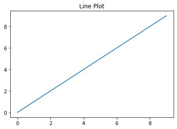

```python
data1 = np.arange(10)

plt.plot(data1)
plt.title('Line Plot'); # ; suppresses print statement
```

#### Histogram

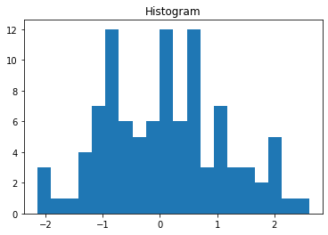

```python
data2 = np.random.randn(100)

plt.hist(data2, bins=20)
plt.title('Histogram');
```

#### Scatter Plot

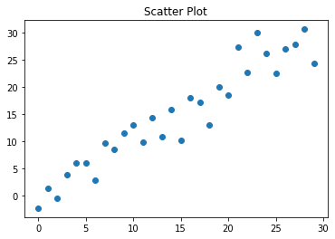

```python
x = np.arange(30)
y = np.arange(30) + 3 * np.random.randn(30)

plt.scatter(x, y)
plt.title('Scatter Plot');
```

#### Bar Plot

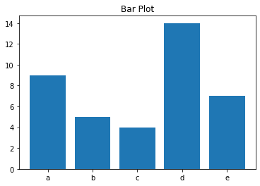

```python
data4 = np.random.randint(low=2, high=20, size=5)
x2 = ['a','b','c','d','e']

plt.bar(x2, data4)
plt.title('Bar Plot');
```

### Subplots

Multiple plots can be added next to each other using [`subplots()`](https://matplotlib.org/api/_as_gen/matplotlib.pyplot.subplots.html).

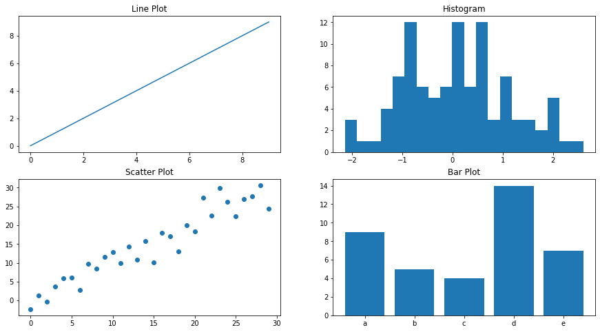

```python
fig, axes = plt.subplots(2,2, figsize=(15,8))

axes[0,0].plot(data1)
axes[0,0].set_title('Line Plot')

axes[0,1].hist(data2, bins=20)
axes[0,1].set_title('Histogram')

axes[1,0].scatter(x, y)
axes[1,0].set_title('Scatter Plot')

axes[1,1].bar(x2, data4)
axes[1,1].set_title('Bar Plot');
```

### 2-D Array as an Image

Images can be considered as array of dimension (m, n). Let's plot some `ndarrays` as images.

Create a random array of dimension (50, 50) and plot as an image.

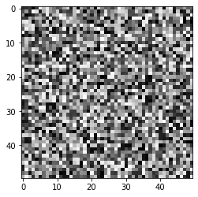

```python
X = np.random.random((50, 50)) # sample 2D array

plt.imshow(X, cmap="gray");
```

Create an array of dimension (15,8) and plot as an image.

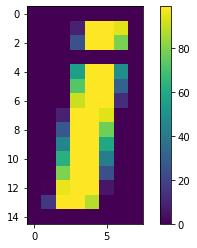

```python
# Create a (15, 8) array
X2 = np.array([[ 0,  0,  0,  0,  0,  0,  0,  0],
               [ 0,  0,  0,  9, 99, 99, 94,  0],
               [ 0,  0,  0, 25, 99, 99, 79,  0],
               [ 0,  0,  0,  0,  0,  0,  0,  0],
               [ 0,  0,  0, 56, 99, 99, 49,  0],
               [ 0,  0,  0, 73, 99, 99, 31,  0],
               [ 0,  0,  0, 91, 99, 99, 13,  0],
               [ 0,  0,  9, 99, 99, 94,  0,  0],
               [ 0,  0, 27, 99, 99, 77,  0,  0],
               [ 0,  0, 45, 99, 99, 59,  0,  0],
               [ 0,  0, 63, 99, 99, 42,  0,  0],
               [ 0,  0, 80, 99, 99, 24,  0,  0],
               [ 0,  1, 96, 99, 99,  6,  0,  0],
               [ 0, 16, 99, 99, 88,  0,  0,  0],
               [ 0,  0,  0,  0,  0,  0,  0,  0]])

plt.imshow(X2)
plt.colorbar();
```

The image displayed is colorful because matplotlib is using the default *colormap* (a mapping from values in the array to colors). The default colormap in matplotlib is *viridis*, which maps low numbers to purple and high numbers to yellow. The relationship of numbers to colors can be seen using colorbar.

*colormap* can be easily changed using the `cmap` argument.

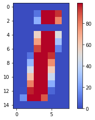

```python
plt.imshow(X2, cmap='coolwarm')
plt.colorbar();
```

### 3-D Surface Plots

Various 3-D plots can be created using matplotlib. 3-D plots are enabled by importing the `mplot3d` toolkit. Once this submodule is imported, a three-dimensional axes can be created by passing the keyword `projection='3d'` to any of the normal axes creation. Let's create a 3-D surface plot.

```python
from mpl_toolkits import mplot3d
```

```python
# Make data
X = np.arange(-5, 5, 0.25)
Y = np.arange(-5, 5, 0.25)
X, Y = np.meshgrid(X, Y)
R = np.sqrt(X**2 + Y**2)
Z = np.sin(R)
```

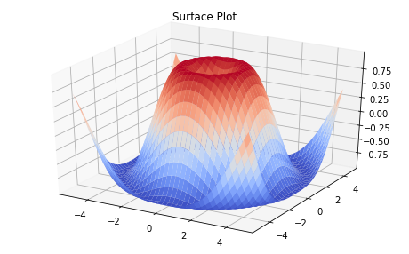

```python
# Plot
fig = plt.figure(figsize=(8,5))
ax = plt.axes(projection='3d')
ax.plot_surface(X, Y, Z, rstride=1, cstride=1,
                cmap='coolwarm', edgecolor='none')
ax.set_title('Surface Plot');
```

## Conclusion

In this part of the guide series we introduced **[NumPy](https://numpy.org/)**, a foundational package for numerical computing in Python. We discussed how N-dimensional arrays `ndarray` can be created and then accessed in multiple ways using indexing and slicing. You have seen in detail how universal functions use the concept of *Vectorization* to perform element-wise operations on arrays. You were also introduced to the basics of plotting arrays.

In the next part of this guide series, you will learn about Introduction to [Pandas](https://pandas.pydata.org/).

## References

[1] Wes McKinney. 2017. Python for Data Analysis: Data Wrangling with Pandas, NumPy, and IPython (2nd. ed.). O'Reilly Media, Inc.

[2] Jake VanderPlas. 2016. Python Data Science Handbook: Essential Tools for Working with Data (1st. ed.). O'Reilly Media, Inc.

[3] Harris, C.R., Millman, K.J., van der Walt, S.J. et al. Array programming with NumPy. Nature 585, 357–362 (2020). https://doi.org/10.1038/s41586-020-2649-2